# ACLED

The Armed Conflict Location & Event Data (ACLED) project maintains a regularly updated database of violent conflict events and non-violent protests around the globe. Data collection and coding is done by humans and relies on newspaper coverage as well as on social media activity, NGO reports, and other data sets that cover specific regions.

For *recent* (2010s to the present) activity outside of the US, this is an ideal source for understanding the number, size, or characteristics of large scale protest cycles. However, it may not be a good source if you’re trying to examine a single small or short lived protest movement because you may not have enough detail to conduct quantitative analyses.

Check here for the [ACLED codebook](https://acleddata.com/knowledge-base/codebook/), or take a look at some of the [recent analyses conducted using ACLED data](https://acleddata.com/analysis/), or take a look at this recent Washington Post article that uses ACLED data to examine [the government crackdown on protests in Myanmar](https://www.washingtonpost.com/world/interactive/2021/myanmar-crackdown-military-coup/).

# Accessing ACLED data

## Step 1: Create an account

Go to https://developer.acleddata.com/ and register to retrieve an API key.

## Step 2: Get an API key

When you have finished, follow the instructions to login and click the “Add New Key” button at the bottom of the page.

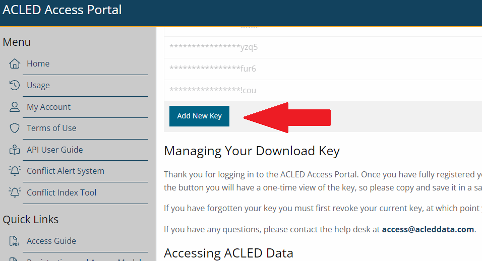

Be sure you copy the key before you click the “I have copied the key” button.

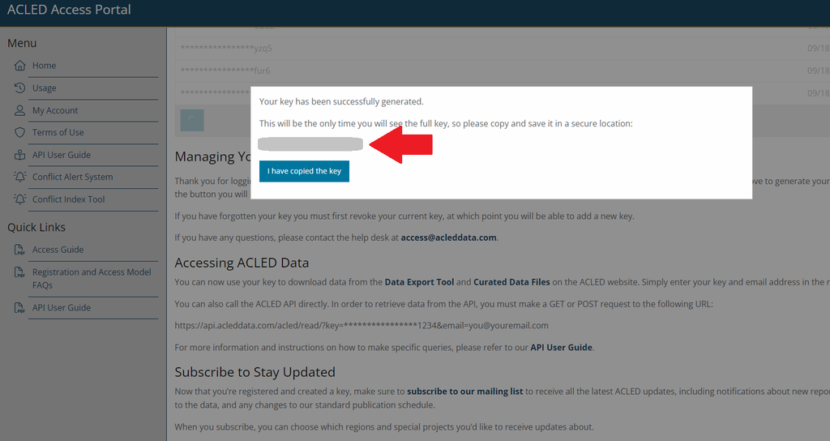

Copy the key

## Step 3: Download data

Now you have two options for accessing data:

### **Option 1:** Data Export Tool

You can use the [Data Export Tool](https://acleddata.com/data-export-tool/) to download data as a .csv file. You’ll want to set some appropriate filters (don’t try to download the entire data set, its massive) and then you’ll want to put your API key in the “Access Key” field.

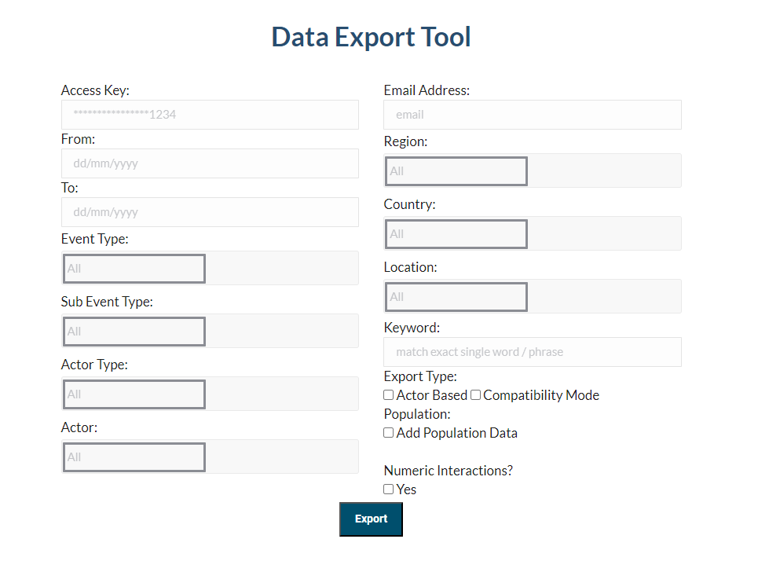

The data export tool

After that, you can import the file into R using the `read_csv` function or by using the Rstudio graphical interface (see [here for some quick instructions](https://support.posit.co/hc/en-us/articles/218611977-Importing-Data-with-the-RStudio-IDE#importing-csv)). If you use the graphical interface, be sure you copy the commands you used to import the data into your script so you can use them later!

### Option 2: Use the ACLED API

Your other option is to use the ACLED API to download data from within R. The `acled.api` package allows us to do this with a single command, but it takes a little setup to get it working.

### Using the ACLED API

First, you’ll want to install the `acled.api` package. Remember that you can install packages by running `install.package("packagname")`. Once you’ve installed a package on your computer, you don’t need to install again. However, you will need to **import** the package every time you reload R if you want to use commands from it. So run `library(acled.api)` to import the package.

Go ahead and install the `usethis` package as well, if you don’t already have it

```r
# install first
install.packages("acled.api")
# also install usethis if you don't have it already
install.packages("usethis")
```

#### Saving your API key in R

The ACLED API package allows you to download data directly from within R, but we’ll need to supply our key in order to make the functions work. Since an API key is sort of like a password that you use to authenticate your identity, **you don’t want to put your key directly in a script.** (After all: you want to be able to re-use and share your scripts, and you don’t want to have a bunch of sensitive information floating around in them)

Instead, we’ll store it as an R environment variable so we can access it later.

If you have the .Renviron installed, you can edit the Renviron by running the code below from within Rstudio

```r
usethis::edit_r_environ()
```

This will open a new page called .Renviron.

You’ll want to write the following lines to this file (swapping in your own API key and email address):

```
ACLED_API_KEY = 'YOUR API KEY in quotes'
ACLED_EMAIL = 'the email you used to register in quotes'
```

[figure not shown]

The .Renviron file

**When you’re done, click `ctrl + s` to save the file, and then restart R-studio.**

Once you restart, you should be able to access those environment variables fromwithin Rstudio by running something like `Sys.getenv('variable_name_here')`.

Running this will return your ACLED email address:

```r
Sys.getenv("ACLED_EMAIL")
```

Running this will return your API key:

```r
Sys.getenv("ACLED_API_KEY")
```

So now you can use these commands in your script without having to type in your key directly.

#### Sending an API request

Now that you have your API Key and email stored in R, you should be able to send requests to the ACLED API. We’ll send a request that finds all events from October 1, 2024, through October 17, 2024:

```r
# load the acled.api library:
library(acled.api)
oct_events<-acled.api(
  email.address = Sys.getenv("ACLED_EMAIL"),
  access.key = Sys.getenv("ACLED_API_KEY"),
  start.date = "2024-10-01",
  end.date ="2024-10-17",
  all.variables = TRUE
)
```

**1**

Adding the access key and email address as environment variables (this avoids putting my api key directly in the Rscript)

**2**

We can (optionally) set a specific start and end date to retrieve. If I left these commands out, I would retrieve everything, but that’s probably not a good idea because there’s a ton of ACLED data.

**3**

By default, this command only returns a subset of the available columns, `all.variables=TRUE` ensures we get all of the stuff that ACLED codes about an event.

Something to keep in mind: when you run this command, you’re sending a request to the servers maintained by the people who run ACLED. They’re probably set up to handle a lot of traffic, but you want to be careful about requesting too much too frequently. So you probably should save your results if you intend to re-use this data.

You can store your results in a .csv file like this:

```r
readr::write_csv(oct_events, "oct_2024_events.csv")
# re-open it by running:
# oct_events <- readr::read_csv("oct_2024_events.csv")
```

Alternatively, you could store them in a `.rds` file (which can only be read by R) like this:

```r
saveRDS(oct_events, "oct_2024_events.rds")
# re-open it by running:
# oct_events<-readRDS("oct_2024_events.rds")
```

Once all is said and done, I would recommend writing the code you used to download and save results all together in one script and saving it separately from the script you’ll be using for your analyses. The final script would look like this:

```r
# load the acled.api library:
library(acled.api)
oct_events<-acled.api(
  email.address = Sys.getenv("ACLED_EMAIL"),
  access.key = Sys.getenv("ACLED_API_KEY"),
  start.date = "2024-10-01",
  end.date ="2024-10-17",
  all.variables = TRUE
)

readr::write_csv(oct_events, "oct_2024_events.csv")
```

#### Example queries

Changing the arguments we supply to the `acled.api` function will change the data we retrieve. You can get a sense of the options available by looking at the help file for that function or [the online documentation](https://cran.r-project.org/web/packages/acled.api/acled.api.pdf).

I’ve included some example queries in the tabs below.

**Filtering by country**

You can select one or more specific countries by adding some names to the “country” argument, and you can modify the date range by changing the `start.date` and `end.date` arguments. Note that the dates are in YYYY-MM-DD format. [Check here for a list of available countries](https://acleddata.com/knowledge-base/country-iso-codes/).

```r
# load the acled.api library:
library(acled.api)

china_india_events<-acled.api(
  email.address = Sys.getenv("ACLED_EMAIL"),
  access.key = Sys.getenv("ACLED_API_KEY"),
  start.date = "2019-01-01",
  end.date ="2021-12-31",
  all.variables = TRUE,
  country = c('China', "India")
)

# save the results
readr::write_csv(china_india_events, "china_india_2019-2021_events.csv")
```

**Filtering on a relative date**

One major advantage of using an API is that I can set up code to always retrieve the latest data regardless of when I run it. The `Sys.Date()` function in R retrieves the current date, and `Sys.Date()-30` retrieves the date 30 days earlier. So the code below will always get the last 30 days worth of data from the U.S., Canada, and Mexico:

```r
# load the acled.api library:
library(acled.api)

na_events<-acled.api(
  email.address = Sys.getenv("ACLED_EMAIL"),
  access.key = Sys.getenv("ACLED_API_KEY"),
  start.date = Sys.Date()-30,
  end.date =Sys.Date(),
  all.variables = TRUE,
  country = c('United States', "Mexico", "Canada")
)

# save the results
readr::write_csv(na_events, "north_america_last_month_events.csv")
```

**Filtering with a custom query**

If you’re already comfortable working with APIs, you can try adding some more complex filters to the request with the `other.query` argument. (You would want to [familiarize yourself with the API User guide first](https://developer.acleddata.com/rehd/cms/views/acled_api/documents/API-User-Guide.pdf)) This query pulls all events involving the Russian private military organization known as the Wagner Group:

```r
# load the acled.api library:
library(acled.api)

wagner_events<-acled.api(
  email.address = Sys.getenv("ACLED_EMAIL"),
  access.key = Sys.getenv("ACLED_API_KEY"),
  all.variables = TRUE,
  other.query = URLencode("actor1=Wagner Group:OR:actor2=Wagner Group")
)

# save the results
readr::write_csv(wagner_events, "wagner_events.csv")
```

# Analyzing the data

Lets go ahead and dig into that October event data again. Remember that you can load a previously saved CSV with the `read_csv` command:

```r
library(tidyverse)
oct_events  <- read_csv("oct_2024_events.csv")
```

ACLED data is not limited to protest activity! They include multiple different kinds of contentious interactions. The general “type” of event is recorded in the `event_type` variable. Remember that you can get counts of a categorical variable using the `count` function, so we can get a sense of the different event types like this:

```r
oct_events|>
  count(event_type)
```

| event_type | n |
| --- | --- |
| Battles | 1580 |
| Explosions/Remote violence | 3803 |
| Protests | 4490 |
| Riots | 512 |
| Strategic developments | 920 |
| Violence against civilians | 830 |

We can get a count of `event_type` by country and assign the results to a new data frame called “country_counts”. We’ll use this data to create some bar plots in the next section.

```r
country_counts <- oct_events|>
  count(event_type, country)
```

### Making a barplot

One thing we might want to do with this result is create a barplot that shows the number of instances of violence against civilians in each country for the relevant time frame. We can use `ggplot` to generate this.

This section will walk you through changing a `ggplot` object step-by-step and seeing how the plot changes after each additional command. Skip to the section titled Making it in one step if you want to see how you would create this with one (long) R command.

Start by filtering by event type to grab only the relevant events:

```r
violence<-country_counts|>
  filter(event_type=='Violence against civilians')
```

Then set up our empty plotting space using the `ggplot` function:

```r
viol_plot <- ggplot(violence, aes(x=country, y=n))
```

Enter “viol_plot” into the console to see what this looks like so far:

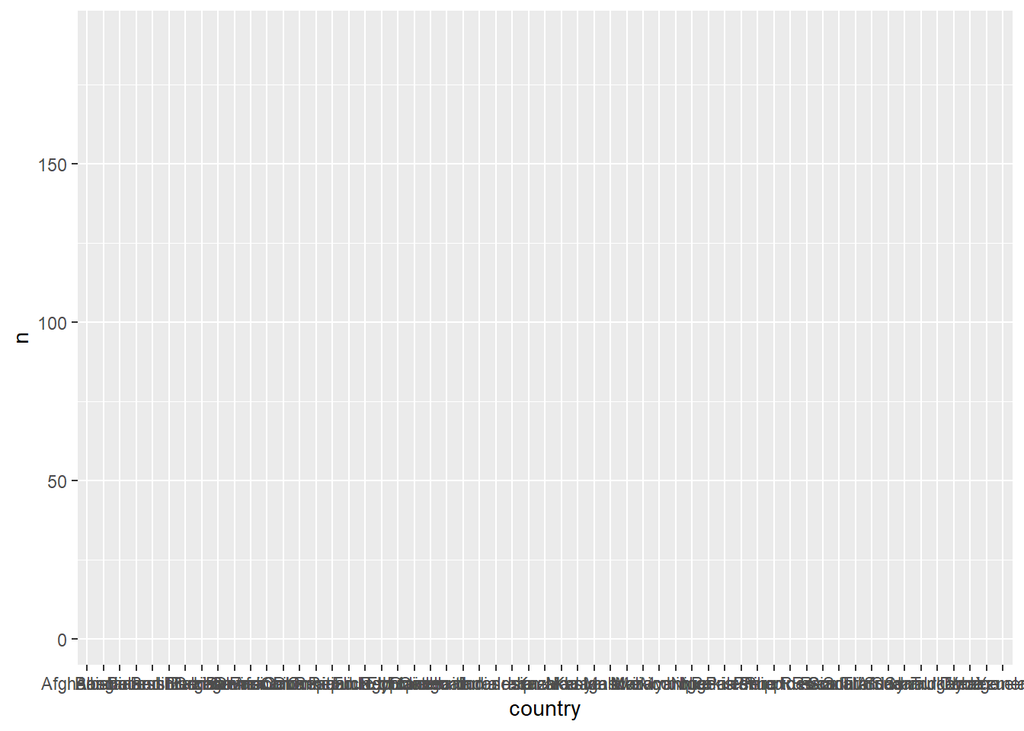

```r
viol_plot
```

You might notice an issue here already! The axis labels are overlapping. We could fix this by creating a really big plotting space, but an easier solution might be to just flip the x and y axis here. We can flip the axes of an existing plot with the `coord_flip` function:

```r
viol_plot<-viol_plot +
  coord_flip()
```

Enter viol_plot in the console to see what this looks like now. You should see something like this:

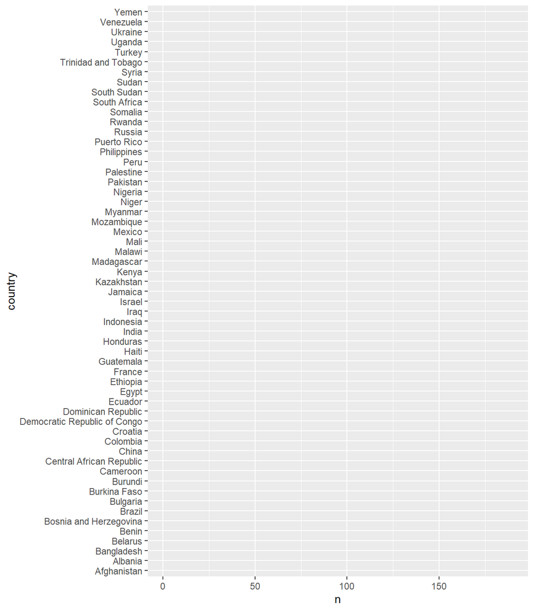

(you might still need to adjust the size of the plotting window to get the axis labels to stop overlapping)

Now that we have our plot set up, we will want to add the bars themselves. We can add a bar with the `geom_bar()` function. (`geom_bar` can produce other summary statistics, so we use `stat="identity"` here because we want the height of each bar to be based on the value of `n`.)

```r
viol_plot <- viol_plot + geom_bar(stat='identity')
```

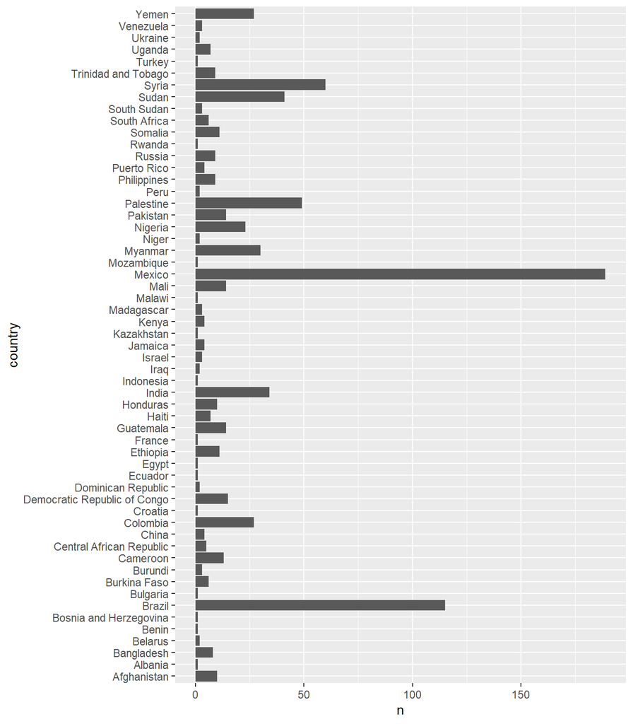

This is much closer! Now a couple of things we might want to modify here. I want to add axis labels, a title, and a caption, and also change the color scheme to a simple black-and-white instead of the greyscale default. I can do that like this:

```r
viol_plot <- viol_plot +
  # x axis label
  xlab("Country") +
  # y axis label
  ylab("Number of events") +
  # title and caption
  labs(title = "Incidents of violence against civilians in October 2024",
              caption = "Data source: ACLED") +
  # black-and-white theme
  theme_bw()
```

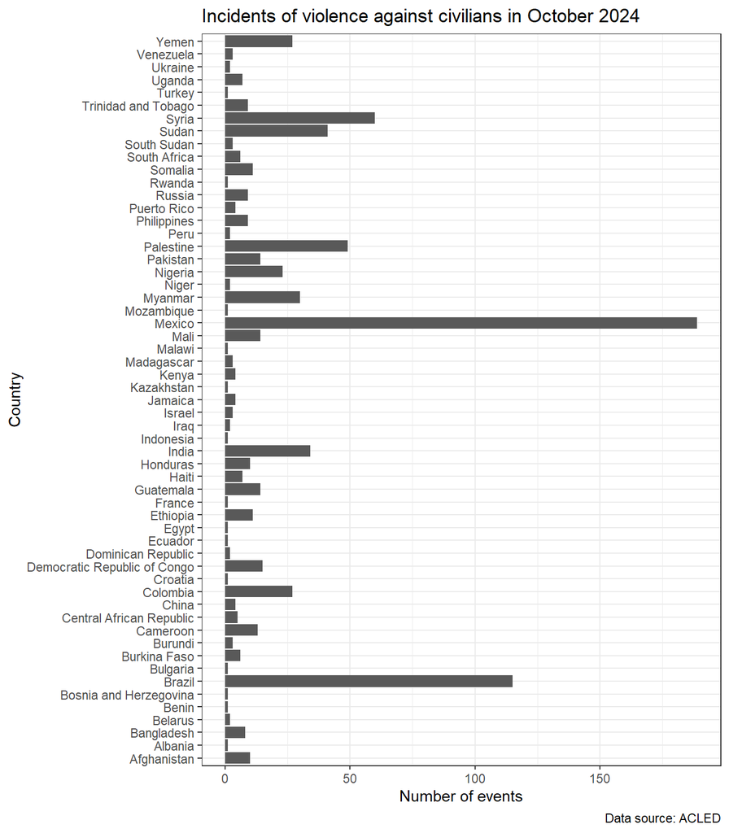

#### Exporting the plot to Word

Once I’m satisfied with my output, I might want to be able to show my result in a Word document. I can actually copy-paste directly from the output window, but this can sometimes result in really low-resolution plots. A better option is to save the plot using `ggsave` and then import it into a word document.

You can use the `width` and `height` arguments to adjust the sizing of your plot. Usually this will require some guessing and checking to get right, but you want to aim for a size that avoids cutting off any relevant information.

```r
ggsave(viol_plot, filename='october_violence.png', width=10, height=8, units='in')
```

Once you have a saved plot, you can import it into a Word document by going to Insert -> Pictures -> Insert picture from this device and then importing the file you just created.

### Making it in one step

We did this in multiple steps so we could see how the changes impacted our output, but we can create this entire barplot with one long block of code. Here’s what it looks like when we just put everything together:

**Original**

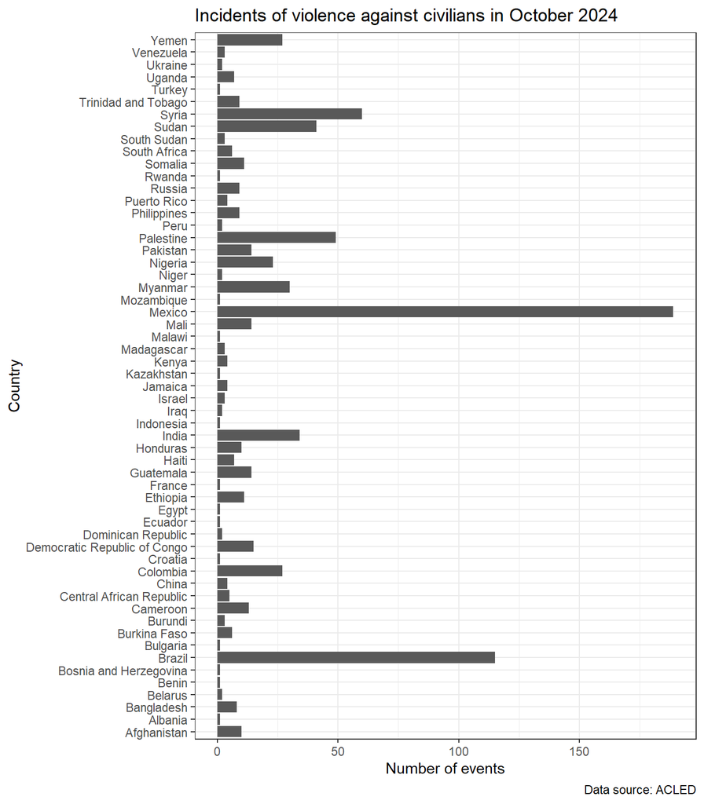

```r
viol_plot <- ggplot(violence, aes(x = country, y = n)) +
  # make it horizontal
  coord_flip() +
  # add the bars
  geom_bar(stat = 'identity') +
  # x axis label
  xlab("Country") +
  # y axis label
  ylab("Number of events") +
  # title and caption
  labs(title = "Incidents of violence against civilians in October 2024",
              caption = "Data source: ACLED") +
  # black-and-white theme
  theme_bw()

viol_plot
```

**Ordered by frequency**

The default setting here sorts these results alphabetically, but we can use the `reorder` function to sort a vector by some other characteristic. Here, I’m making the same plot but ordering based on the value of `n`:

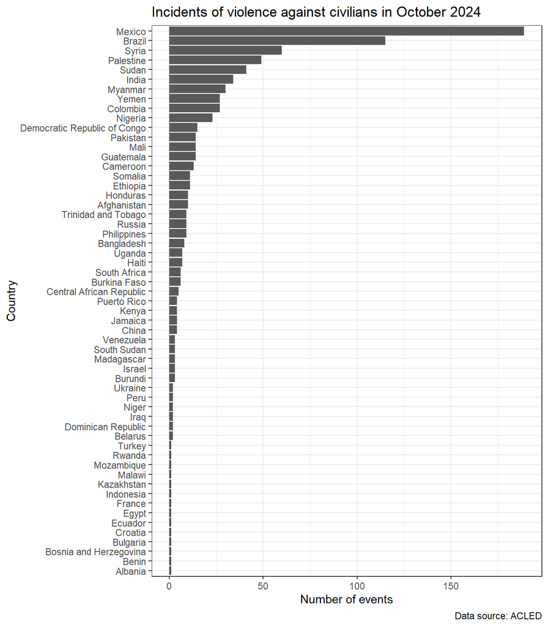

```r
viol_plot <- ggplot(violence, aes(x = reorder(country, n), y = n)) +
  # make it horizontal
  coord_flip() +
  # add the bars
  geom_bar(stat = 'identity') +
  # x axis label
  xlab("Country") +
  # y axis label
  ylab("Number of events") +
  # title and caption
  labs(title = "Incidents of violence against civilians in October 2024",
              caption = "Data source: ACLED") +
  # black-and-white theme
  theme_bw()

viol_plot
```

**Ordered by frequency with a different fill color**

We can also set the fill color manually to change the bars from solid black to something more visually appealling. (of course, if you’re printing this in black and white, this might make things event less visible!)

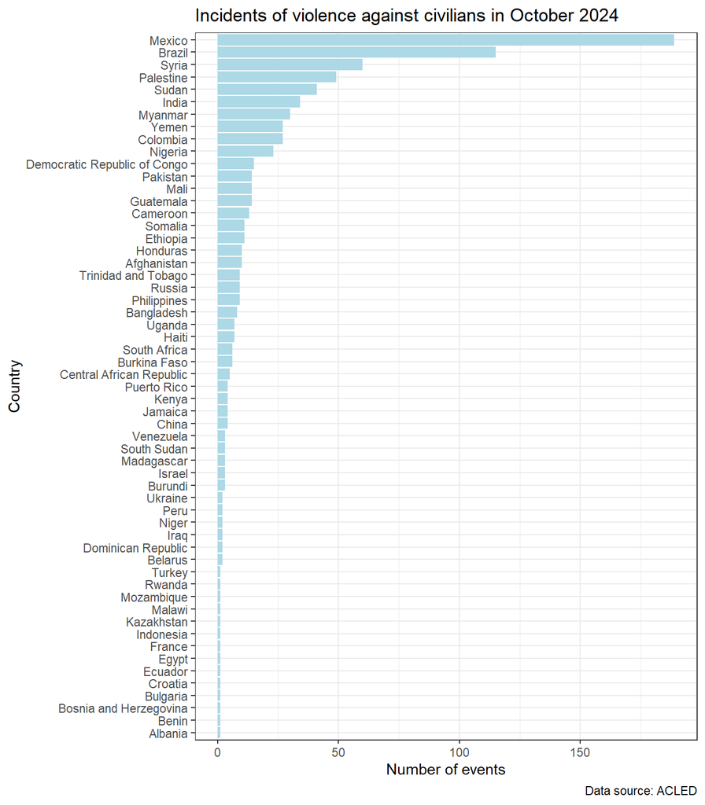

```r
viol_plot <- ggplot(violence, aes(x = reorder(country, n), y = n)) +
  # make it horizontal
  coord_flip() +
  # add the bars
  geom_bar(stat = 'identity', fill='lightblue') +
  # x axis label
  xlab("Country") +
  # y axis label
  ylab("Number of events") +
  # title and caption
  labs(title = "Incidents of violence against civilians in October 2024",
              caption = "Data source: ACLED") +
  # black-and-white theme
  theme_bw()


viol_plot
```

# Additional info and documentation

- [Codebook](https://acleddata.com/knowledge-base/codebook/)
- [List of Countries/Date ranges covered in ACLED data](https://acleddata.com/knowledge-base/country-time-period-coverage/)
- [Curated Datasets](https://acleddata.com/curated-data-files/)
- [The ACLED knowledge base](https://acleddata.com/knowledge-base/)